# people_analytics

## Case Description

The HRD department receives many complaints about many employees leaving the company and complaints about poor employee performance.  
Lead of people wants to prevent employee turnover as well as increase employee performance.  
In order to resolve the problems, he assigned you to make a data product that help him to assess the problems.  
Lead of people needs to assess:  
How bad is the employee turnover and How bad is the employee performance?

### Dataset Overview

The dataset consist of people analytics data in ABC Company

Features in dataset:

Employee ID

Gender: Male / Female

Age: Numeric

Education: Education Level (Primary - Ph.D.)

Department: Company Department (e.g. marketing, operational, etc.)

Performance Rating: Employee performance rating assesed by their manager

Absent: Number of days employee unplanned period of being away from work

Turnover: leaving employee from the organization

ESI 1: Employee satisfaction index survey result for question 1 in likert scale (1-10)

ESI 2: Employee satisfaction index survey result for question 2 in likert scale (1-10)

ESI 3: Employee satisfaction index survey result for question 3 in likert scale (1-10)

Promoted this year: Binary (Yes/No)

Complete the Training Course: Binary (Yes/No)

Training Evaluation Score: Score of employee training evaluation

Min. pass training eval. score: Minium training evaluation score

## Importing Libraries

```python
import pandas as pd
import numpy as np
import seaborn as sns
import warnings
import matplotlib.pyplot as plt

warnings.filterwarnings('ignore')
sns.set_palette('tab10')
```

```python
df = pd.read_excel('Dataset Liveclass week 3.xlsx')
df.head()
```

|  | Employe ID | Gender | Age | Education | Department | Performance Rating | Absent | Turnover | ESI 1 | ESI 2 | ESI 3 | Promoted This Year | Complete the Training Course | Training Evaluation Score | Min. Training Pass Eval. Score |
| --- | --- | --- | --- | --- | --- | --- | --- | --- | --- | --- | --- | --- | --- | --- | --- |
| 0 | BCGX7377 | Male | 27 | Master’s degree | Business Development | 7.92 | 1 | No | 9 | 8 | 6 | No | Yes | 98 | 70 |
| 1 | BCGX4795 | Male | 44 | Higher education (Bachelor’s degree) | Engineering | 5.94 | 7 | No | 8 | 10 | 9 | No | No | 91 | 70 |
| 2 | BCGX4007 | Female | 21 | Higher education (Bachelor’s degree) | Human Resources | 9.90 | 0 | No | 8 | 10 | 10 | Yes | No | 62 | 70 |
| 3 | BCGX9524 | Male | 47 | Higher education (Bachelor’s degree) | Business Development | 9.90 | 5 | No | 7 | 9 | 8 | Yes | No | 77 | 70 |
| 4 | BCGX8426 | Female | 46 | Doctor of Philosophy (Ph.D.) | Product Management | 7.92 | 4 | No | 9 | 9 | 9 | No | Yes | 85 | 70 |

```python
df.isnull().sum()
```

```
Employe ID                        0
Gender                            0
Age                               0
Education                         0
Department                        0
Performance Rating                0
Absent                            0
Turnover                          0
ESI 1                             0
ESI 2                             0
ESI 3                             0
Promoted This Year                0
Complete the Training Course      0
Training Evaluation Score         0
Min. Training Pass Eval. Score    0
dtype: int64
```

## Explanatory Data Analysis

```python
df.describe()
```

|  | Age | Performance Rating | Absent | ESI 1 | ESI 2 | ESI 3 | Training Evaluation Score | Min. Training Pass Eval. Score |
| --- | --- | --- | --- | --- | --- | --- | --- | --- |
| count | 854.000000 | 854.000000 | 854.000000 | 854.000000 | 854.000000 | 854.000000 | 854.000000 | 854.0 |
| mean | 34.853630 | 7.554157 | 3.809133 | 7.613583 | 8.090164 | 7.785714 | 80.477752 | 70.0 |
| std | 9.330125 | 1.247926 | 2.094454 | 1.457681 | 1.433994 | 1.474991 | 12.015576 | 0.0 |
| min | 19.000000 | 5.090000 | 0.000000 | 5.000000 | 5.000000 | 5.000000 | 59.000000 | 70.0 |
| 25% | 27.000000 | 6.930000 | 2.000000 | 6.000000 | 7.000000 | 6.000000 | 70.000000 | 70.0 |
| 50% | 35.000000 | 7.570000 | 4.000000 | 7.000000 | 8.000000 | 8.000000 | 83.000000 | 70.0 |
| 75% | 43.000000 | 8.320000 | 6.000000 | 9.000000 | 9.000000 | 9.000000 | 89.000000 | 70.0 |
| max | 51.000000 | 9.900000 | 7.000000 | 10.000000 | 10.000000 | 10.000000 | 100.000000 | 70.0 |

```python
col_object = df.select_dtypes(include='object').columns
for col in col_object[1:]:
    print('{}: {}'.format(col,pd.unique(df[col])))
```

```
Gender: ['Male' 'Female']
Education: ['Master’s degree' 'Higher education (Bachelor’s degree)'
 'Doctor of Philosophy (Ph.D.)' 'Secondary education' 'Primary education']
Department: ['Business Development' 'Engineering' 'Human Resources'
 'Product Management' 'Creative' 'Data' 'Quality Assurance' 'Finance'
 'Legal' 'Operations' 'Marketing' 'Sales']
Turnover: ['No' 'Yes' 'v']
Promoted This Year: ['No' 'Yes']
Complete the Training Course: ['Yes' 'No']
```

```python
df['Turnover'] = df['Turnover'].replace({'v':'Yes'})
print('{}: {}'.format('Turnover',pd.unique(df['Turnover'])))
```

```
Turnover: ['No' 'Yes']
```

Numerical Histogram

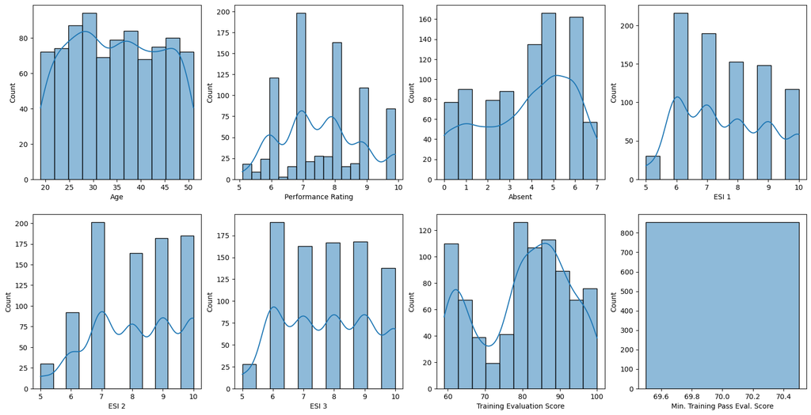

```python
fig, axs = plt.subplots(nrows=2,ncols=4,figsize=(20,10))
sns.histplot(data=df,x='Age',ax=axs[0][0],kde=True)
sns.histplot(data=df,x='Performance Rating',ax=axs[0][1],kde=True)
sns.histplot(data=df,x='Absent',ax=axs[0][2],kde=True)
sns.histplot(data=df,x='ESI 1',ax=axs[0][3],kde=True)
sns.histplot(data=df,x='ESI 2',ax=axs[1][0],kde=True)
sns.histplot(data=df,x='ESI 3',ax=axs[1][1],kde=True)
sns.histplot(data=df,x='Training Evaluation Score',ax=axs[1][2],kde=True)
sns.histplot(data=df,x='Min. Training Pass Eval. Score', ax=axs[1][3],kde=True)
```

### EDA Numerical

Age distribution is uniform enough

Performance Rating as it's peak at around 7

Few employee (<30) are Detractor (<6)(unsatisfied with work environment) look by ESI

By looking at Training Evaluation Score, very few people has average score, either the're poor or good performance

Categorical Histogram

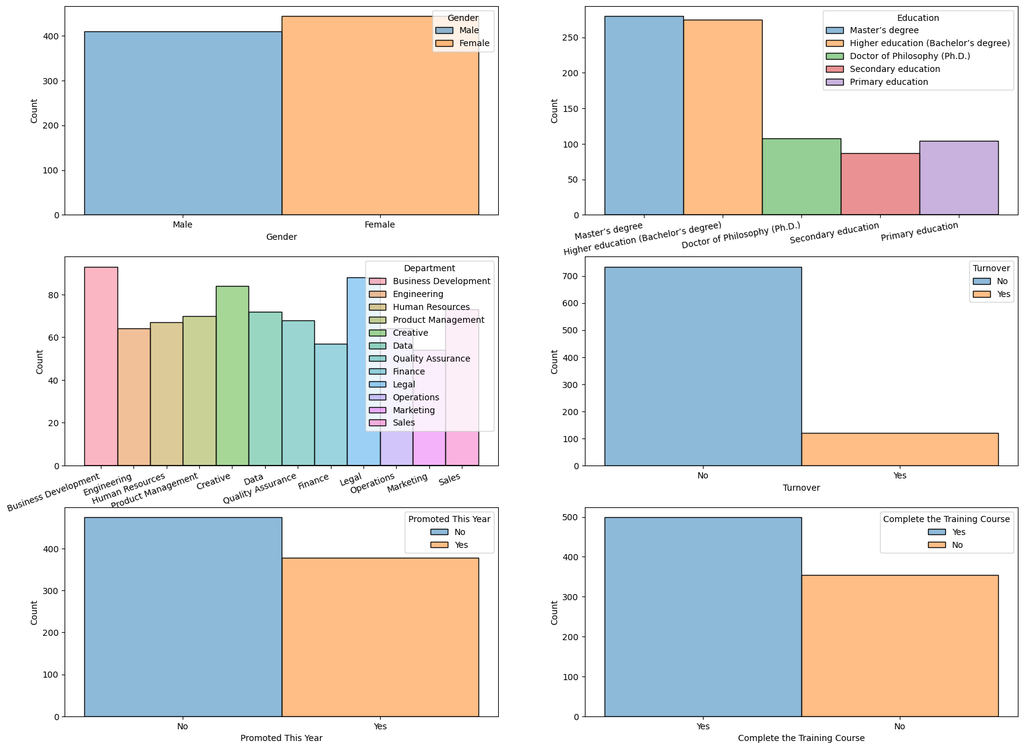

```python
fig, axs = plt.subplots(nrows=3,ncols=2,figsize=(20,15))
sns.histplot(data=df,x='Gender',ax=axs[0][0],hue='Gender')
sns.histplot(data=df,x='Education',ax=axs[0][1],hue='Education')
sns.histplot(data=df,x='Department',ax=axs[1][0],hue='Department')
sns.histplot(data=df,x='Turnover',ax=axs[1][1],hue='Turnover')
sns.histplot(data=df,x='Promoted This Year',ax=axs[2][0],hue='Promoted This Year')
sns.histplot(data=df,x='Complete the Training Course',ax=axs[2][1],hue='Complete the Training Course')

axs[0][1].set_xticks(axs[0][1].get_xticks(), axs[0][1].get_xticklabels(), rotation=10, ha='right')
axs[1][0].set_xticks(axs[1][0].get_xticks(), axs[1][0].get_xticklabels(), rotation=20, ha='right')

plt.show()
```

### EDA Categorical

Distribution of Gender is similar enough with Female dominated

Legal and Business Development dominated the department distribution

Most of our employee are from Bachelor and Master Degree

```python
# # Replace boolean column with binary
# df = df.replace({'No': 0, 'Yes': 1, 'Female': 0, 'Male': 1})
# for col in col_object[1:]:
#     print('{}: {}'.format(col,pd.unique(df[col])))
```

### Calculate People Analytics Metrics

```python
# Turnover rate
num_employee = df['Employe ID'].nunique()
turnover = df['Turnover'].value_counts()['Yes']
turnover_rate = turnover/num_employee
print('Number Employee: ', num_employee)
print('Turnover Employee: ',turnover)
print('Turnover Rate: {:.3f}%'.format(turnover_rate*100))
```

```
Number Employee:  825
Turnover Employee:  120
Turnover Rate: 14.545%
```

```python
# Course Complete Rate
complete_course = df['Complete the Training Course'].value_counts()['Yes']
ccr = complete_course/num_employee
print('Number Course Completed: ', complete_course)
print('Course Complete Rate: {:.3f}%'.format(ccr*100))
```

```
Number Course Completed:  499
Course Complete Rate: 60.485%
```

```python
# Assesment Pass Rate
min_score = df['Min. Training Pass Eval. Score'].mean()
pass_employee = df[df['Training Evaluation Score'] > min_score].count()[0]
apr = pass_employee/num_employee
print('Number Assesment Pass (score >{}): {}'.format(min_score,pass_employee))
print('Assesment Pass Rate: {:.3f}%'.format(apr*100))
```

```
Number Assesment Pass (score >70.0): 638
Assesment Pass Rate: 77.333%
```

```python
# Average Performance Rating
total_pr = df['Performance Rating'].sum()
apr = total_pr/num_employee
print('Average Performance Rating: {:.3f}/10'.format(apr))
```

```
Average Performance Rating: 7.820/10
```

```python
# Absence Rate
# Assume thare's 229 working days
avg_absence = df['Absent'].sum() / num_employee
absence_rate = avg_absence/229
print('Total Day Absence: ', df['Absent'].sum())
print('Average Absence each Employee: {:.3f} days'.format(avg_absence))
print("Absence Rate: {:.3f}%".format(absence_rate*100))
```

```
Total Day Absence:  3253
Average Absence each Employee: 3.943 days
Absence Rate: 1.722%
```

```python
# Promoted Rate
num_promoted = df['Promoted This Year'].value_counts()['Yes']
pr = num_promoted / num_employee
print("Number of Promoted Employee: ",num_promoted)
print("Promoted Rate: {:.3f}%".format(pr*100))
```

```
Number of Promoted Employee:  379
Promoted Rate: 45.939%
```

```python
# Employee Satisfaction Index (ESI)
df['ESI'] = (((df['ESI 1'] + df['ESI 2'] + df['ESI 3'])/3)-1)*100/9
print("Employee Satisfaction Index (ESI) Min: {:.3f}".format(df['ESI'].min()))
print("Employee Satisfaction Index (ESI) Average: {:.3f}".format(df['ESI'].mean()))
print("Employee Satisfaction Index (ESI) Max: {:.3f}".format(df['ESI'].max()))
```

```
Employee Satisfaction Index (ESI) Min: 44.444
Employee Satisfaction Index (ESI) Average: 75.887
Employee Satisfaction Index (ESI) Max: 100.000
```

### Turnover Distribution

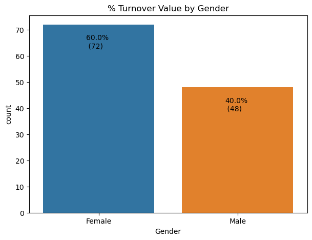

```python
turnover_df = df[df['Turnover'] == 'Yes']
_, axs = plt.subplots(figsize=(7,5))
fig = sns.countplot(turnover_df,x='Gender',ax=axs)
axs.set_title('% Turnover Value by Gender')
total = df['Turnover'].value_counts()['Yes']
for p in fig.patches:
    percent = '{:.1f}%\n ({:.0f})'.format(p.get_height()*100/total,p.get_height())
    x = p.get_x() + p.get_width()/2 - 0.09
    y = p.get_y() + p.get_height() - 9
    fig.annotate(percent, (x, y))
```

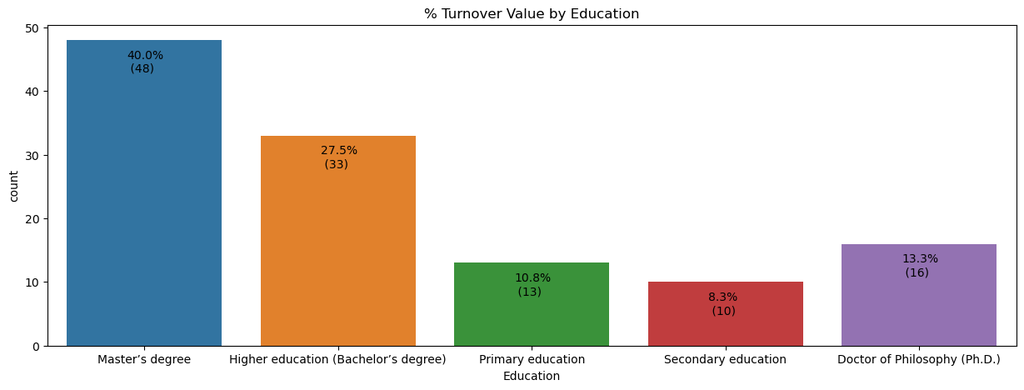

```python
_, axs = plt.subplots(figsize=(15,5))
fig = sns.countplot(turnover_df,x='Education',ax=axs)
axs.set_title('% Turnover Value by Education')
total = df['Turnover'].value_counts()['Yes']
for p in fig.patches:
    percent = '{:.1f}%\n ({:.0f})'.format(p.get_height()*100/total,p.get_height())
    x = p.get_x() + p.get_width()/2 - 0.09
    y = p.get_y() + p.get_height() - 5
    fig.annotate(percent, (x, y))
```

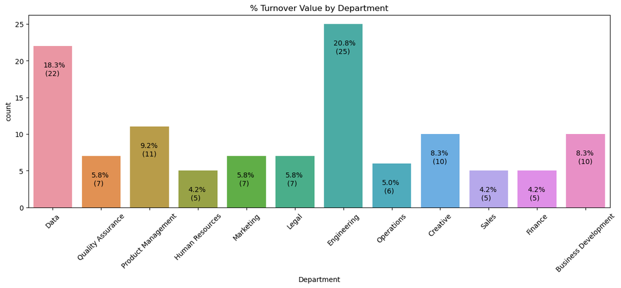

```python
_, axs = plt.subplots(figsize=(15,5))
fig = sns.countplot(turnover_df,x='Department',ax=axs)
axs.set_title('% Turnover Value by Department')
axs.tick_params(axis='x', rotation=45)
total = df['Turnover'].value_counts()['Yes']
for p in fig.patches:
    percent = '{:.1f}%\n ({:.0f})'.format(p.get_height()*100/total,p.get_height())
    x = p.get_x() + p.get_width()/2 - 0.2
    y = p.get_y() + p.get_height() - 4
    fig.annotate(percent, (x, y))
```

### Performance Rating Distribution

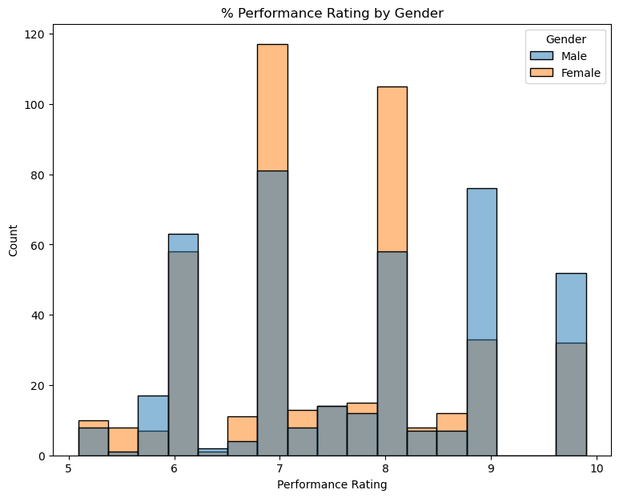

```python
_, axs = plt.subplots(figsize=(9,7))
sns.histplot(df,x='Performance Rating',hue='Gender',ax=axs)
axs.set_title('% Performance Rating by Gender')
```

### Promotion Distribution

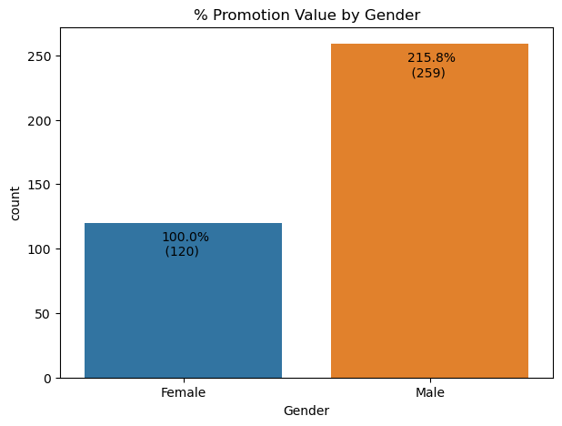

```python
promotion_df = df[df['Promoted This Year'] == 'Yes']
_, axs = plt.subplots(figsize=(7,5))
fig = sns.countplot(promotion_df,x='Gender',ax=axs)
axs.set_title('% Promotion Value by Gender')
total = df['Turnover'].value_counts()['Yes']
for p in fig.patches:
    percent = '{:.1f}%\n ({:.0f})'.format(p.get_height()*100/total,p.get_height())
    x = p.get_x() + p.get_width()/2 - 0.09
    y = p.get_y() + p.get_height() - 25
    fig.annotate(percent, (x, y))
```

### Correlation Matrix of Turnover

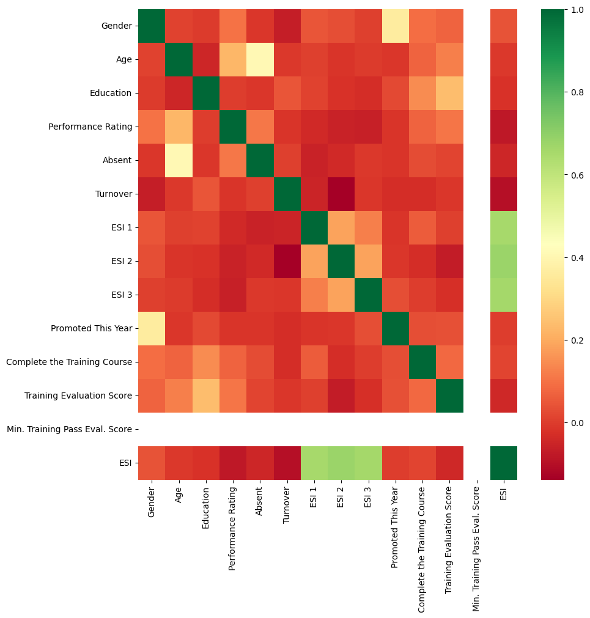

```python
df2 = df.copy()
df2 = df2.replace(({'Yes':1,'No':0,'Female':0,'Male':1,'Primary education':0,'Secondary education':1,'Higher education (Bachelor’s degree)':2,
                                'Master’s degree':3,'Doctor of Philosophy (Ph.D.)':4}))
_, axs = plt.subplots(figsize=(10,10))
sns.heatmap(df2.select_dtypes(exclude='object').corr(),ax=axs,cmap="RdYlGn")
```

### Causal Inference by XGBoost SHAP value

```python
import shap
from sklearn.model_selection import train_test_split
from sklearn.ensemble import RandomForestRegressor
import xgboost as xgb
```

```python
Y = df2['Turnover']
X = df2.drop(columns=['Employe ID','Department','Turnover','Min. Training Pass Eval. Score'])
```

```python
n_trees = 500
dmat = xgb.DMatrix(X, Y)
bst  = xgb.train({"tree_method": "gpu_hist"}, dmat, n_trees)
# Make sure GPU prediction is enabled
bst.set_param({"predictor": "gpu_predictor"})
```

```python
shap_values = bst.predict(dmat, pred_contribs=True)
```

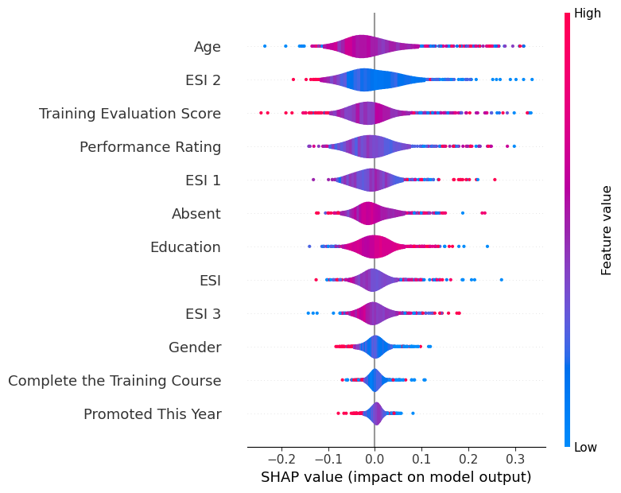

```python
shap.summary_plot(shap_values[:,:-1], X, plot_type='violin')
```

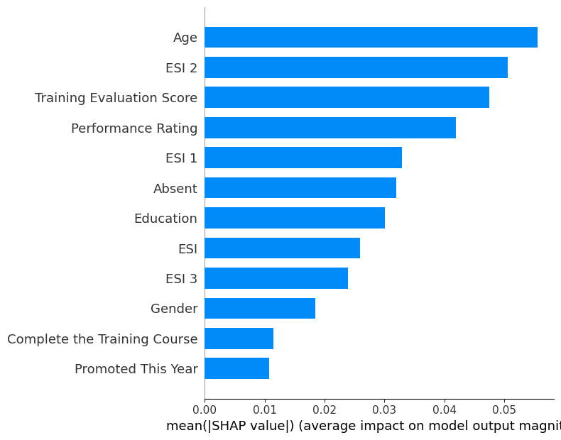

```python
shap.summary_plot(shap_values[:,:-1], X, plot_type='bar')
```